# PIE benchmark: CLUinPy’s CLUMondo allocation of every estimator’s surface

Published

November 21, 2026

CLUinPy is a Python re-implementation of CLUMondo (van Asselen & Verburg 2013). The work happens in `040-alloc-cluinpy/run_pie.py`; this step only calls it, so that the pipeline runs from `execute-all.sh`.

- **Suitability, the crossing**: each estimator’s class probability map from `020-potentials.r`, as CLUinPy’s suitability stack, with only the viable conversions allowed (`010`).
- **Suitability, as shipped** (reference, runs 8601…): CLUinPy’s own suitability module, logistic regression on the three factors (VIF filtering, RFECV feature selection, presence against an equal number of absences per class), fitted on the *1991* map, with all conversions allowed: like lulcc, the CLUE paradigm of where each class is. Its tutorial fits on a spatially thinned sample (10 % per class, capped at 500 cells) and holds out 30 % for AUC; `run_pie.py` bypasses both, so it sees every cell like evoland’s learners.
- **Demand**: one service per class (its area, identity service and conversion matrices), prescribed as the observed 1999 totals and allocated from the 1991 map in one step, like every other allocator here. Convergence tolerance 0.1 % of demand as shipped (the tutorial’s 2 % leaves ~700 built cells unallocated on this case) and 0.5 % in the crossing: on the Weights of Evidence surface, binned into ranges so that many cells tie, a small change in elasticity flips a whole group of cells, and the loop oscillates around 0.25 % without reaching 0.1 %. The same tolerance holds for every estimator; the quantity disagreement in `050` shows the cost.
- **Parameters**, the same for both: conversion resistance 0.8 (forest), 1 (built), 0.6 (other) and a 3 × 3 neighbourhood weight of 0.3 for built land only, after the tutorial’s values for comparable classes.
- CLUinPy draws its demand-adjustment speed from Python’s `random`; each realisation seeds it. That speed is CLUinPy’s only randomness: it changes where within the tolerance the demand loop stops.
- **Iterations.** CLUMondo raises a class’s demand elasticity by the relative demand gap per iteration, in shrinking steps. With the crossing’s class probabilities (about 0.97 for the current class, a few per cent for any change), built land needs an elasticity of about 0.8 before it outbids forest: 20–1 600 iterations, against 10–800 as shipped. The limit is 30 000.

Needs the repository’s uv environment (`uv sync` at the repository root), which holds CLUinPy’s dependencies, GDAL bindings included. CLUinPy itself is not an installable package; `python-env.r` clones it at its pinned commit on first use.

```r
source("2026-09-model-comparison/common.r")
source("python-env.r")
cluinpy_dir <- cluinpy_repo()
cluinpy_python <- project_python()
reset_timings("cluinpy")
run_cluinpy <- function(n, ...) {
  processx::run(
    cluinpy_python,
    c(file.path(pie_dir, "040-alloc-cluinpy", "run_pie.py"), cluinpy_dir, n, ...),
    env = c(
      "current",
      PYTHONPATH = cluinpy_pythonpath(cluinpy_dir)
    ),
    echo = FALSE,
    error_on_status = TRUE
  )
}
members <- crossing_members()[allocator == "clumondo"]
for (est in estimators$estimator) {
  res <- run_cluinpy(
    members[estimator == est, .N],
    "crossing",
    file.path(outputs_dir, "suitability", paste0(est, ".tif")),
    external_maps_dir("clumondo", est),
    # realisation i is seeded seed_base + i
    members[estimator == est & member == 1L, seed] - 1L
  )
}
native <- native_pipelines[native == "cluinpy"]
res <- run_cluinpy(
  native$n_members,
  "native",
  "",
  file.path(outputs_dir, "maps", "cluinpy"),
  10000L + native$id_run + native$offset
)
# the last year's convergence of the last realisation
tail(strsplit(res$stdout, "\n")[[1]], 3)
```

```
[1] "year: 1999, loop: 339, totdiff: 0.0, maxdiff: 0.10214250124564025, differences: [ 0.10102503  0.         -0.1021425 ] ,elasticities: [-0.26663387  0.30577222  0.13660198]"
[2] "year: 1999, loop: 340, totdiff: 0.0, maxdiff: 0.10214250124564025, differences: [ 0.10102503  0.         -0.1021425 ] ,elasticities: [-0.2666666   0.30577222  0.13663507]"
[3] "year: 1999, loop: 341, totdiff: 0.0, maxdiff: 0.09363295880149813, differences: [ 0.09363296 -0.00572836 -0.09217738] ,elasticities: [-0.2666969   0.30577406  0.13666491]"
```

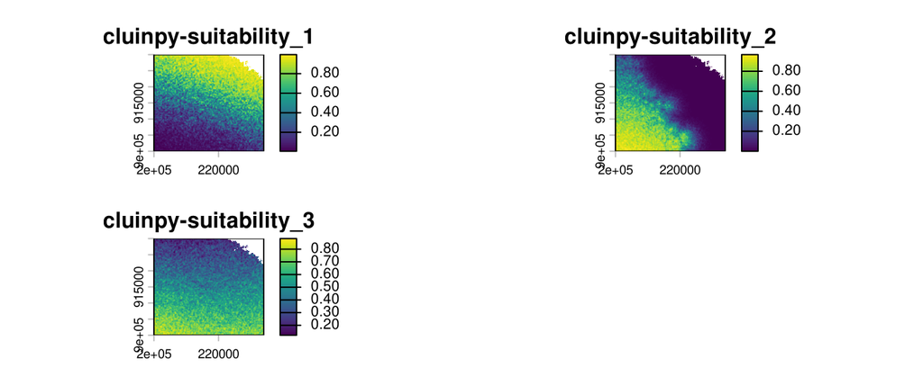

```r
terra::plot(terra::rast(file.path(outputs_dir, "maps", "cluinpy-suitability.tif")))
```

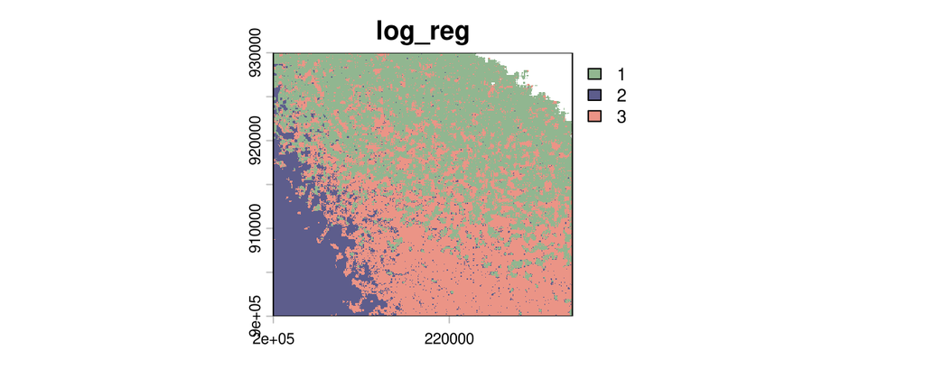

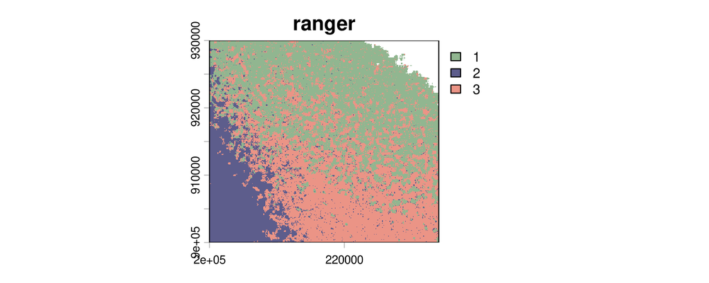

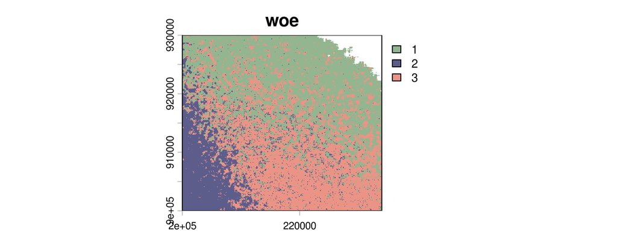

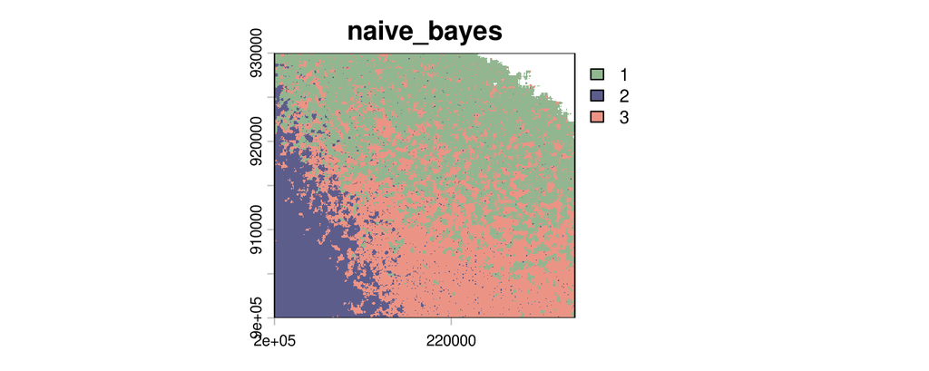

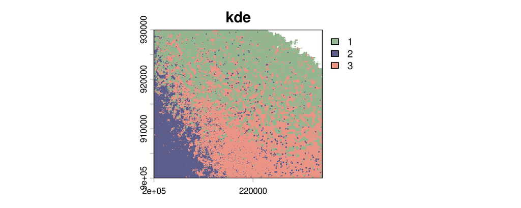

```r
for (est in estimators$estimator) {
  terra::plot(
    terra::rast(file.path(
      external_maps_dir("clumondo", est),
      sprintf("r%02d.tif", n_realisations)
    )),
    col = lulc_colours,
    main = est
  )
}
```